## Linear Regression for Prostate

### Selecting the training data

```r
data_Set <- read.table("prostate.txt")
training_data <- subset(data_Set, train == "TRUE")
validation_data <- subset(data_Set, train == "FALSE")
validation_data <- subset(validation_data[, 1:9])
```

### Data Exploration

#### One Variable Statistic Summary

For one variable statistic summary, we will remove the train column

```r
training_data <- subset(training_data[, 1:9])
summary(training_data)
```

```
##      lcavol           lweight           age             lbph
##  Min.   :-1.3471   Min.   :2.375   Min.   :41.00   Min.   :-1.38629
##  1st Qu.: 0.4883   1st Qu.:3.330   1st Qu.:61.00   1st Qu.:-1.38629
##  Median : 1.4679   Median :3.599   Median :65.00   Median :-0.05129
##  Mean   : 1.3135   Mean   :3.626   Mean   :64.75   Mean   : 0.07144
##  3rd Qu.: 2.3491   3rd Qu.:3.884   3rd Qu.:69.00   3rd Qu.: 1.54751
##  Max.   : 3.8210   Max.   :4.780   Max.   :79.00   Max.   : 2.32630
##       svi              lcp             gleason          pgg45
##  Min.   :0.0000   Min.   :-1.3863   Min.   :6.000   Min.   :  0.00
##  1st Qu.:0.0000   1st Qu.:-1.3863   1st Qu.:6.000   1st Qu.:  0.00
##  Median :0.0000   Median :-0.7985   Median :7.000   Median : 15.00
##  Mean   :0.2239   Mean   :-0.2142   Mean   :6.731   Mean   : 26.27
##  3rd Qu.:0.0000   3rd Qu.: 0.9948   3rd Qu.:7.000   3rd Qu.: 50.00
##  Max.   :1.0000   Max.   : 2.6568   Max.   :9.000   Max.   :100.00
##       lpsa
##  Min.   :-0.4308
##  1st Qu.: 1.6673
##  Median : 2.5688
##  Mean   : 2.4523
##  3rd Qu.: 3.3652
##  Max.   : 5.4775
```

Let us scale the data for predictors to mean zero

```r
scaled_train_data <- cbind(scale(training_data[,1:8]), training_data$lpsa)
colnames(scaled_train_data)[9] = "lpsa"
scaled_predictors <- subset(scaled_train_data[, 1:8])
```

#### Outliers

BoxPlot for checking the outlier on predictors

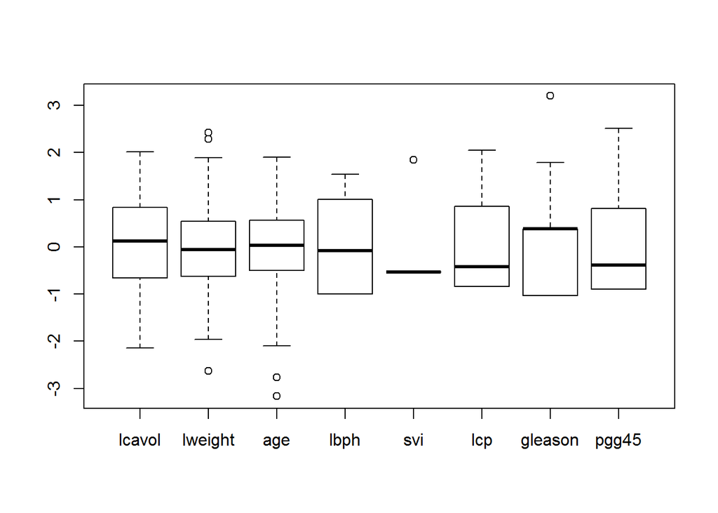

```r
boxplot(scaled_predictors)
```

From boxplot we can check that there might be 3 outliers for weight, 1 for svi and 1 gleason We will work with all the datasets, considering them as rare values.

#### 2 Column Summary

Now for 2 column summary, we will check the correlation

```r
cor(scaled_train_data)
```

```
##             lcavol    lweight       age        lbph        svi         lcp
## lcavol  1.00000000 0.30023199 0.2863243  0.06316772  0.5929491  0.69204308
## lweight 0.30023199 1.00000000 0.3167235  0.43704154  0.1810545  0.15682859
## age     0.28632427 0.31672347 1.0000000  0.28734645  0.1289023  0.17295140
## lbph    0.06316772 0.43704154 0.2873464  1.00000000 -0.1391468 -0.08853456
## svi     0.59294913 0.18105448 0.1289023 -0.13914680  1.0000000  0.67124021
## lcp     0.69204308 0.15682859 0.1729514 -0.08853456  0.6712402  1.00000000
## gleason 0.42641407 0.02355821 0.3659151  0.03299215  0.3068754  0.47643684
## pgg45   0.48316136 0.07416632 0.2758057 -0.03040382  0.4813577  0.66253335
## lpsa    0.73315515 0.48521519 0.2276424  0.26293763  0.5568864  0.48920320
##            gleason       pgg45      lpsa
## lcavol  0.42641407  0.48316136 0.7331551
## lweight 0.02355821  0.07416632 0.4852152
## age     0.36591512  0.27580573 0.2276424
## lbph    0.03299215 -0.03040382 0.2629376
## svi     0.30687537  0.48135774 0.5568864
## lcp     0.47643684  0.66253335 0.4892032
## gleason 1.00000000  0.75705650 0.3424278
## pgg45   0.75705650  1.00000000 0.4480480
## lpsa    0.34242781  0.44804795 1.0000000
```

From the above correlation chart, we can say that lcavol has highest correlation with lpsa and age has lowest correlation.

#### Missing Values

```r
is.na(scaled_train_data)
```

```
##    lcavol lweight   age  lbph   svi   lcp gleason pgg45  lpsa
## 1   FALSE   FALSE FALSE FALSE FALSE FALSE   FALSE FALSE FALSE
## 2   FALSE   FALSE FALSE FALSE FALSE FALSE   FALSE FALSE FALSE
## 3   FALSE   FALSE FALSE FALSE FALSE FALSE   FALSE FALSE FALSE
## 4   FALSE   FALSE FALSE FALSE FALSE FALSE   FALSE FALSE FALSE
## 5   FALSE   FALSE FALSE FALSE FALSE FALSE   FALSE FALSE FALSE
## 6   FALSE   FALSE FALSE FALSE FALSE FALSE   FALSE FALSE FALSE
## 8   FALSE   FALSE FALSE FALSE FALSE FALSE   FALSE FALSE FALSE
## 11  FALSE   FALSE FALSE FALSE FALSE FALSE   FALSE FALSE FALSE
## 12  FALSE   FALSE FALSE FALSE FALSE FALSE   FALSE FALSE FALSE
## 13  FALSE   FALSE FALSE FALSE FALSE FALSE   FALSE FALSE FALSE
## 14  FALSE   FALSE FALSE FALSE FALSE FALSE   FALSE FALSE FALSE
## 16  FALSE   FALSE FALSE FALSE FALSE FALSE   FALSE FALSE FALSE
## 17  FALSE   FALSE FALSE FALSE FALSE FALSE   FALSE FALSE FALSE
## 18  FALSE   FALSE FALSE FALSE FALSE FALSE   FALSE FALSE FALSE
```

[output cut: 53 more lines]

As there is no True, so there is no missing values in our data.

### Assumption of Normality

This is for linear model with all the predictors

```r
linear_model <- lm(formula = lpsa ~ lcavol + lweight + age + lbph + svi + lcp + gleason + pgg45, data = training_data)
summary(linear_model)
```

```
##
## Call:
## lm(formula = lpsa ~ lcavol + lweight + age + lbph + svi + lcp +
##     gleason + pgg45, data = training_data)
##
## Residuals:
##      Min       1Q   Median       3Q      Max
## -1.64870 -0.34147 -0.05424  0.44941  1.48675
##
## Coefficients:
##              Estimate Std. Error t value Pr(>|t|)
## (Intercept)  0.429170   1.553588   0.276  0.78334
## lcavol       0.576543   0.107438   5.366 1.47e-06 ***
## lweight      0.614020   0.223216   2.751  0.00792 **
## age         -0.019001   0.013612  -1.396  0.16806
## lbph         0.144848   0.070457   2.056  0.04431 *
## svi          0.737209   0.298555   2.469  0.01651 *
## lcp         -0.206324   0.110516  -1.867  0.06697 .
## gleason     -0.029503   0.201136  -0.147  0.88389
## pgg45        0.009465   0.005447   1.738  0.08755 .
## ---
## Signif. codes:  0 '***' 0.001 '**' 0.01 '*' 0.05 '.' 0.1 ' ' 1
##
## Residual standard error: 0.7123 on 58 degrees of freedom
## Multiple R-squared:  0.6944, Adjusted R-squared:  0.6522
## F-statistic: 16.47 on 8 and 58 DF,  p-value: 2.042e-12
```

So qq plot from the residuals obtained is as follows

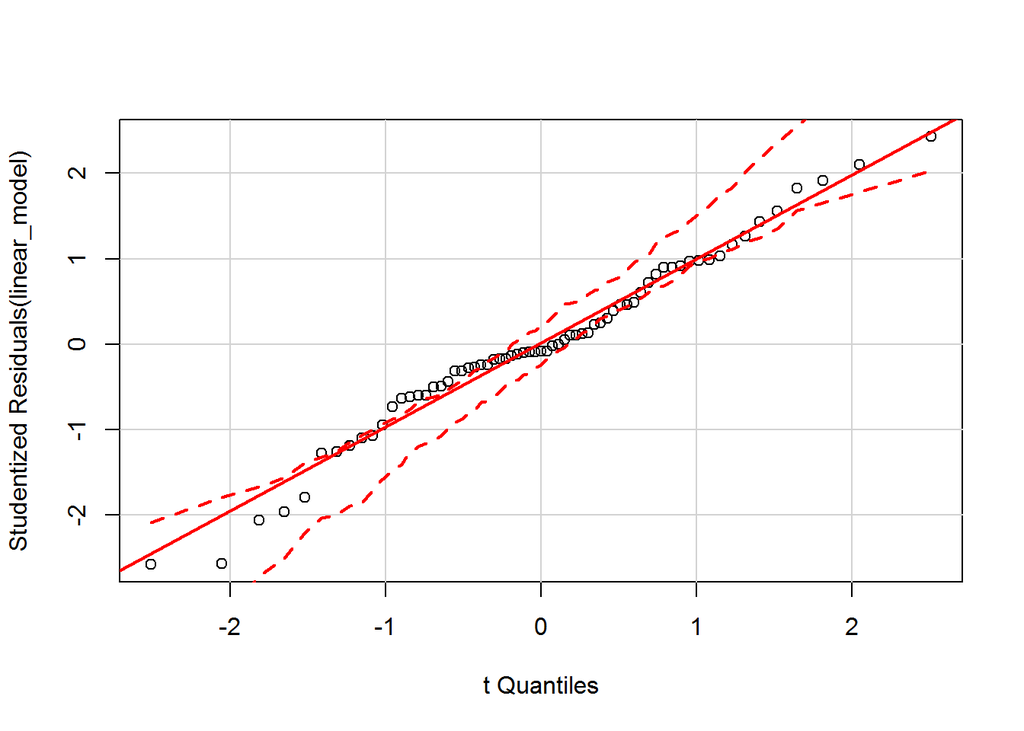

```r
#install.packages("car")
library(car)
qqPlot(linear_model)
```

From QQ plot, we can say that it has somewhat straight line, so residuals are normally distributed.

### Variable Selection

To perform variable selection, using all subsets selection, we will use leap library

#### Exhaustive Search

```r
require(leaps)
scaled_train_data <- as.data.frame(scaled_train_data)
exh <- regsubsets(lpsa~.,data = scaled_train_data, method = "exhaustive")
```

```r
plot(exh,scale = "adjr2")
```

[output not shown]

#### Backward Search

```r
back <- regsubsets(lpsa~.,data = scaled_train_data, method = "backward")
plot(back,scale = "adjr2")
```

[output not shown]

#### Forward Search

```r
fwd <- regsubsets(lpsa~.,data = scaled_train_data, method = "forward")
plot(fwd,scale = "adjr2")
```

[output not shown]

Using adjr2 graph, we can eliminate gleason from our set of predictors.

Model using Variable Selection from exhausitive search is -

```r
linear_model_var <- lm(formula = lpsa ~ lcavol + lweight + age + lbph + svi + lcp + pgg45, data = training_data)
summary(linear_model_var)
```

```
##
## Call:
## lm(formula = lpsa ~ lcavol + lweight + age + lbph + svi + lcp +
##     pgg45, data = training_data)
##
## Residuals:
##      Min       1Q   Median       3Q      Max
## -1.65425 -0.34471 -0.05615  0.44380  1.48952
##
## Coefficients:
##              Estimate Std. Error t value Pr(>|t|)
## (Intercept)  0.259062   1.025170   0.253   0.8014
## lcavol       0.573930   0.105069   5.462 9.88e-07 ***
## lweight      0.619209   0.218560   2.833   0.0063 **
## age         -0.019480   0.013105  -1.486   0.1425
## lbph         0.144426   0.069812   2.069   0.0430 *
## svi          0.741781   0.294451   2.519   0.0145 *
## lcp         -0.205417   0.109424  -1.877   0.0654 .
## pgg45        0.008945   0.004099   2.182   0.0331 *
## ---
## Signif. codes:  0 '***' 0.001 '**' 0.01 '*' 0.05 '.' 0.1 ' ' 1
##
## Residual standard error: 0.7064 on 59 degrees of freedom
## Multiple R-squared:  0.6943, Adjusted R-squared:  0.658
## F-statistic: 19.14 on 7 and 59 DF,  p-value: 4.496e-13
```

#### Statistical Variable Selection

```r
library(caret)
train_control <- trainControl(method="cv", number=10)
linear_model_cv <- lm(formula = lpsa ~ lcavol + lweight + age + lbph + svi + lcp + pgg45 + gleason,
                      data = data_Set, trControl=train_control, method = "lm")

summary(linear_model_cv)
```

```
##
## Call:
## lm(formula = lpsa ~ lcavol + lweight + age + lbph + svi + lcp +
##     pgg45 + gleason, data = data_Set, method = "lm", trControl = train_control)
##
## Residuals:
##      Min       1Q   Median       3Q      Max
## -1.76644 -0.35510 -0.00328  0.38087  1.55770
##
## Coefficients:
##              Estimate Std. Error t value Pr(>|t|)
## (Intercept)  0.181561   1.320568   0.137  0.89096
## lcavol       0.564341   0.087833   6.425 6.55e-09 ***
## lweight      0.622020   0.200897   3.096  0.00263 **
## age         -0.021248   0.011084  -1.917  0.05848 .
## lbph         0.096713   0.057913   1.670  0.09848 .
## svi          0.761673   0.241176   3.158  0.00218 **
## lcp         -0.106051   0.089868  -1.180  0.24115
## pgg45        0.004458   0.004365   1.021  0.31000
## gleason      0.049228   0.155341   0.317  0.75207
## ---
## Signif. codes:  0 '***' 0.001 '**' 0.01 '*' 0.05 '.' 0.1 ' ' 1
##
## Residual standard error: 0.6995 on 88 degrees of freedom
## Multiple R-squared:  0.6634, Adjusted R-squared:  0.6328
## F-statistic: 21.68 on 8 and 88 DF,  p-value: < 2.2e-16
```

#### Performance Evaluation

Prediction using model with all predictors

```r
predict_lpsa <- predict(linear_model,validation_data)
mean_sq_error <- mean((predict_lpsa-validation_data$lpsa)^2)
print(mean_sq_error)
```

```
## [1] 0.521274
```

Prediction using model from all subset selection

```r
predict_lpsa_sub <- predict(linear_model_var,validation_data)
mean_sq_error_sub <- mean((predict_lpsa_sub-validation_data$lpsa)^2)
print(mean_sq_error_sub)
```

```
## [1] 0.5165135
```

Prediction using model from Cross Validation

```r
predict_lpsa_cv <- predict(linear_model_cv,validation_data)
mean_sq_error_cv <- mean((predict_lpsa_cv-validation_data$lpsa)^2)
print(mean_sq_error_cv)
```

```
## [1] 0.413683
```

### Interpretation of Results

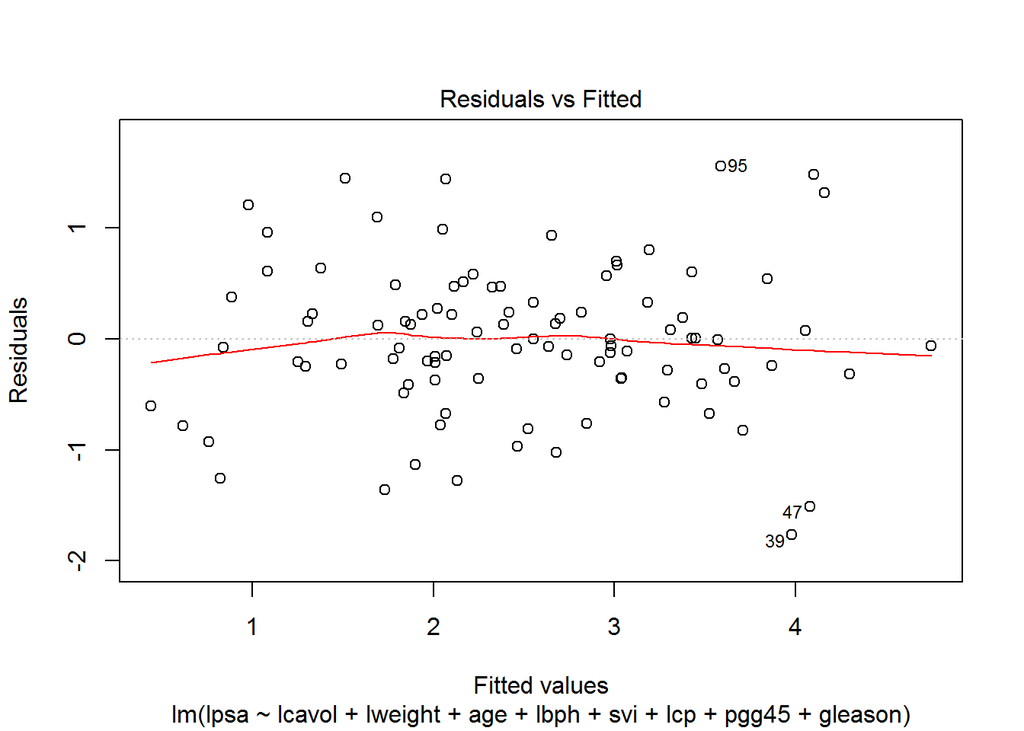

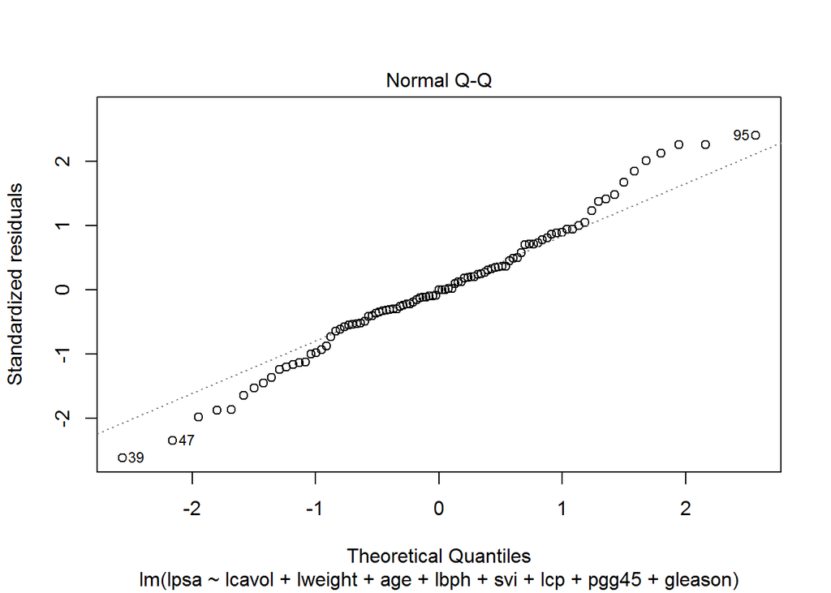

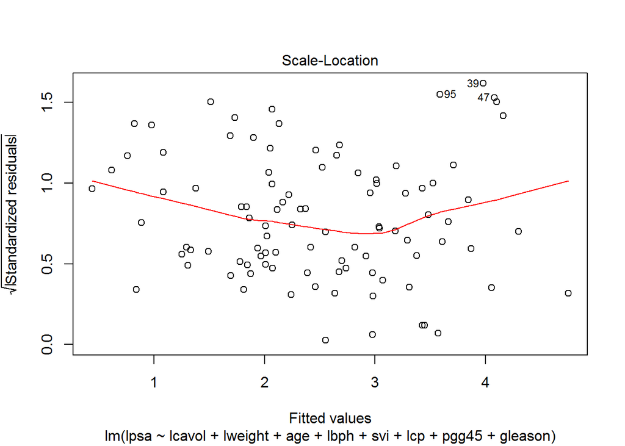

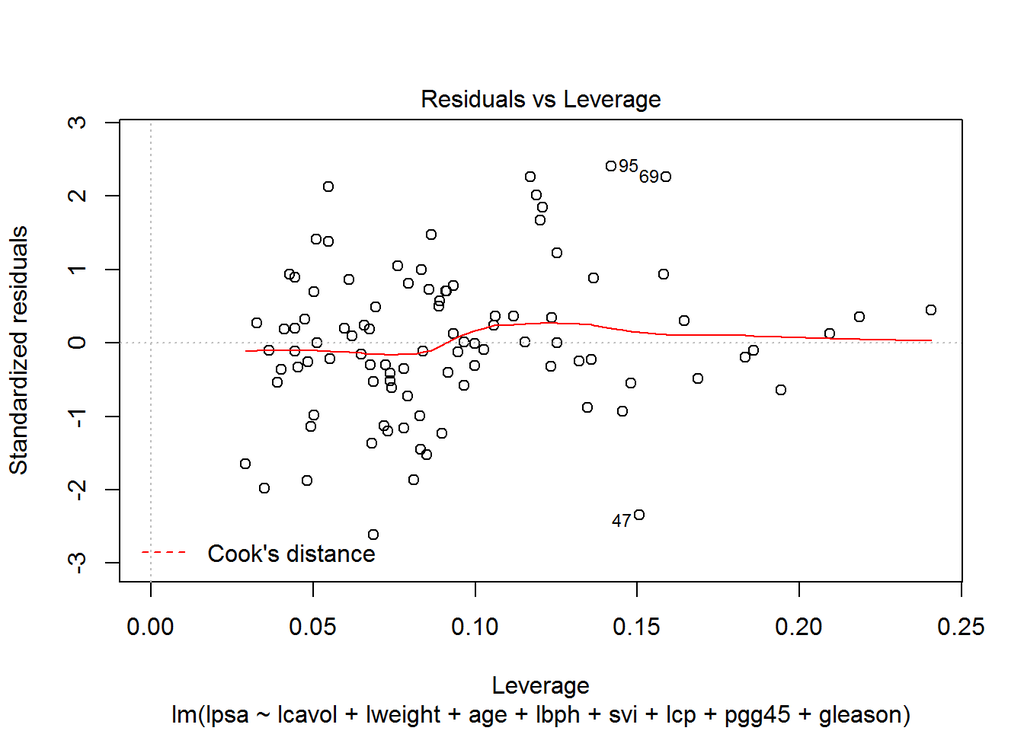

```r
plot(linear_model_cv)
```